# Aula 6 - Análise de Tendência e Sazonalidade

João Ricardo F. de Lima

23 de Agosto de 2023.

# 1 Análise da Tendência

A **tendência determinística** de uma série temporal é representada por mudanças no nível médio da série que ocorrem de forma previsível, em função do tempo. Existe ainda a **Tendência Estocástica**, uma tendência que muda de forma aleatória ao longo do tempo.

Enquanto a tendência determinística representa variações percentuais fixas ao longo do tempo, a tendência estocástica implica em uma variação percentual aleatória e imprevisível.

Supondo que os componentes Ciclo e Sazonalidade não estejam presentes em uma série temporal ($Y_t$), a mesma pode ser representada por

$$Y_t=T_t+\epsilon_t$$

em que $T_t$ é o componente de tendência e $\epsilon_t$ é o resíduo do modelo.

Existem vários métodos para estimar a tendência determinística $T_t$, sendo que os mais utilizados são os métodos de regressão ou Filtro de Hodrick-Prescott.

No método de regressão, ajusta-se $Y_t$ como uma função do tempo:

$$Y_t=f(t)+\epsilon_t$$

em que f(t) pode assumir a forma de um polinômio de qualquer grau ou exponencial. Tem-se as seguintes possibilidades:

1. Tendência Linear: $Y_t=\beta_0+\beta_1t+\epsilon_t$
2. Tendência Quadrática: $Y_t=\beta_0+\beta_1t+\beta_2t^2+\epsilon_t$
3. Polinômio de grau k: $Y_t=\beta_0+\beta_1t+\beta_2t^2+\dots+\beta_kt^k+\epsilon_t$
4. Exponencial: $Y_t=Ae^{\beta t}\epsilon_t$

a variável explicativa nestes modelos é o tempo (t) que assume os valores t=1,2,3,…T, chamada de variável tendência (trend).

## 1.1 Entrando com os dados no R

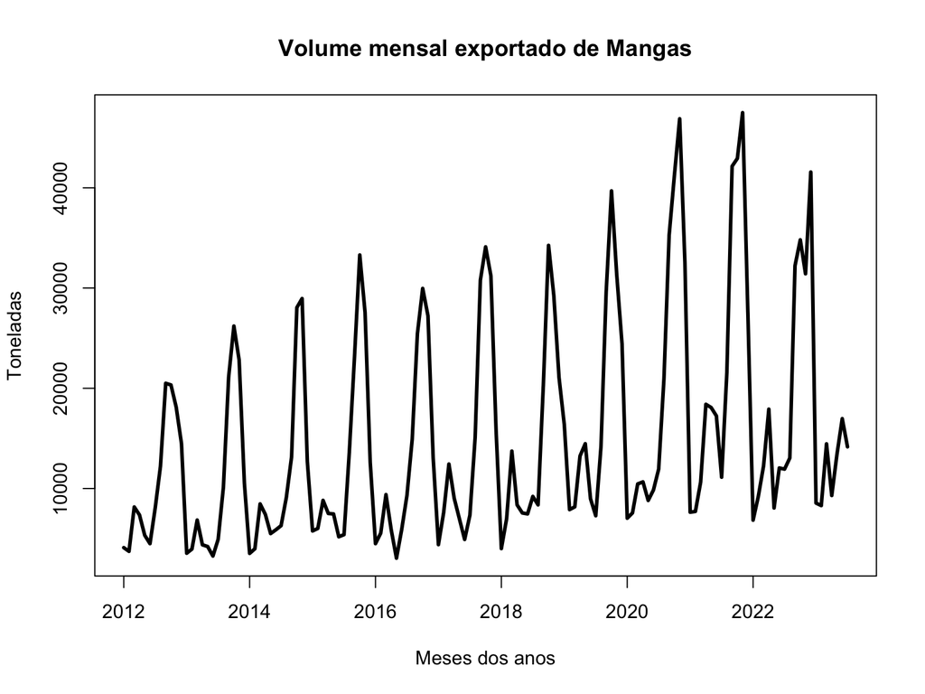

```r
#Direcionado o R para o Diretorio a ser trabalhado
setwd('/Users/jricardofl/Dropbox/tempecon/dados_manga')

#Inicio do Script
#Pacotes a serem utilizados
library(mFilter)
library(forecast)
library(dplyr)
library(tsutils)
library(ggplot2)
library(reshape2)
library(greybox)
library(scales)

atual <-  as.Date("2023-07-01") #ultimo mes disponibilizado
mes <- 7

#Entrando dados no R
dados2 <- read.csv2('total_exporta_br.csv', header=T, sep=";", dec = ".")
#dados <- dados[,-c(9:10)] #retirar as ultimas colunas
colnames(dados2)[1]<-'ano'

#Ajusta para Volume
#Analise de Serie Temporal
exporta_manga_volume <- dados2[,4]
exporta_manga_volume<-exporta_manga_volume/1000  #passando de quilo para tonelada

#Setando como uma série temporal
exporta_manga_volume <- ts(exporta_manga_volume, start=c(2012,1), freq=12)

#Grafico da evolucao do volume exportado de manga
plot(exporta_manga_volume, main='Volume mensal exportado de Mangas',
     xlab='Meses dos anos', ylab='Toneladas', lwd=3)
```

## 1.2 Decomposição da Série Temporal nos componentes

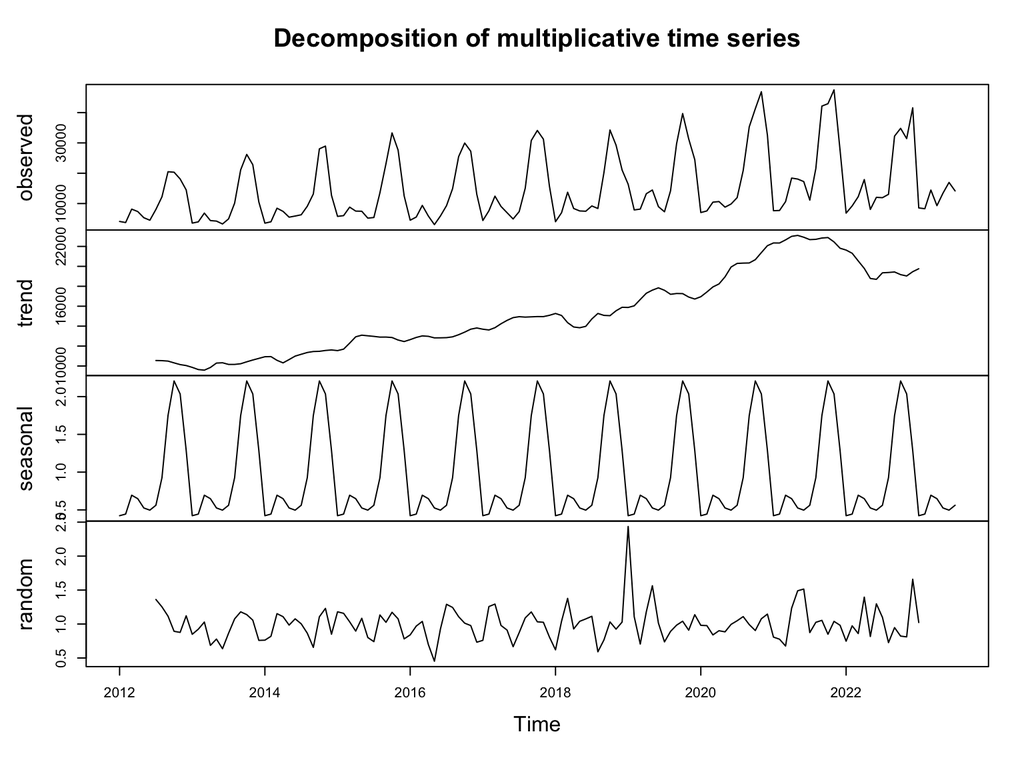

```r
#Decompor a Serie
decompa <- decompose(exporta_manga_volume, type = 'multiplicative')
plot(decompa)
```

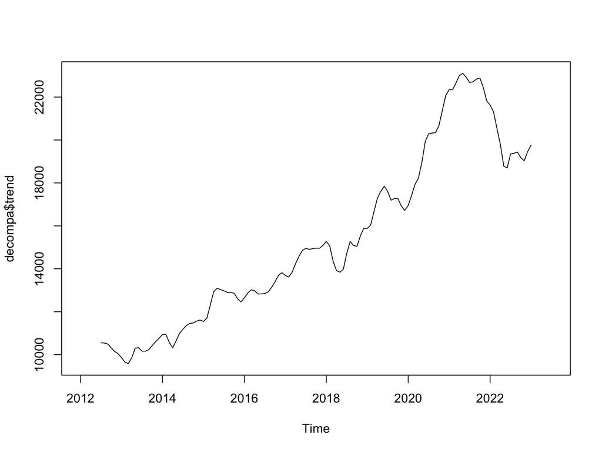

```r
#Mostrar apenas a Tendencia da Serie
plot(decompa$trend)
```

## 1.3 Estimação de Modelos de Tendência

```r
# Modelos estimados com a Série Original
trend <- 1:length(exporta_manga_volume) #geracao da variavel tendencia

regress1 <- lm(exporta_manga_volume ~ trend) #tendencia linear
summary(regress1)
```

```
#
# Call:
# lm(formula = exporta_manga_volume ~ trend)
#
# Residuals:
#    Min     1Q Median     3Q    Max
# -13046  -7485  -3633   5972  28327
#
# Coefficients:
#             Estimate Std. Error t value Pr(>|t|)
# (Intercept)  8387.24    1737.85   4.826 3.66e-06 ***
# trend          95.05      21.54   4.413 2.05e-05 ***
# ---
# Signif. codes:  0 '***' 0.001 '**' 0.01 '*' 0.05 '.' 0.1 ' ' 1
#
# Residual standard error: 10190 on 137 degrees of freedom
# Multiple R-squared:  0.1244,  Adjusted R-squared:  0.1181
# F-statistic: 19.47 on 1 and 137 DF,  p-value: 2.05e-05
```

```r
regress2 <- lm(exporta_manga_volume ~ trend +  I(trend^2)) #tendencia quadratica
summary(regress2)
```

```
#
# Call:
# lm(formula = exporta_manga_volume ~ trend + I(trend^2))
#
# Residuals:
#    Min     1Q Median     3Q    Max
# -12755  -7634  -3588   6092  28256
#
# Coefficients:
#              Estimate Std. Error t value Pr(>|t|)
# (Intercept) 7420.5502  2637.8220   2.813  0.00563 **
# trend        136.1823    86.9870   1.566  0.11978
# I(trend^2)    -0.2938     0.6019  -0.488  0.62620
# ---
# Signif. codes:  0 '***' 0.001 '**' 0.01 '*' 0.05 '.' 0.1 ' ' 1
#
# Residual standard error: 10220 on 136 degrees of freedom
# Multiple R-squared:  0.126,   Adjusted R-squared:  0.1131
# F-statistic: 9.801 on 2 and 136 DF,  p-value: 0.0001055
```

A escolha do modelo que melhor ajusta a série é feita pelo $R^2$ ajustado no caso de terem a mesma variável dependente e quantidades diferentes de variáveis explicativas ou dos critérios de Akaike (AIC) e Schwarz (SC) quando as variáveis dependentes forem diferentes.

## 1.4 Verificação do modelo com melhor ajuste

```r
AIC(regress1, regress2)
```

```
#          df      AIC
# regress1  3 2964.137
# regress2  4 2965.893
```

```r
AICc(regress1)
```

```
# [1] 2962.225
```

```r
AICc(regress2)
```

```
# [1] 2964.071
```

```r
BIC(regress1, regress2)
```

```
#          df      BIC
# regress1  3 2972.940
# regress2  4 2977.631
```

```r
# Modelos estimados com a Série Apenas com a Tendência

exporta_tendencia <- decompa$trend

exporta_tendencia <- ts(exporta_tendencia, start=c(2012,1), freq=12)

trend <- 1:length(exporta_tendencia) #geracao da variavel tendencia

regress3 <- lm(exporta_tendencia ~ trend) #tendencia linear
summary(regress3)
```

```
#
# Call:
# lm(formula = exporta_tendencia ~ trend)
#
# Residuals:
#     Min      1Q  Median      3Q     Max
# -2590.2  -737.7  -185.2   455.5  3350.0
#
# Coefficients:
#             Estimate Std. Error t value Pr(>|t|)
# (Intercept) 8073.932    253.692   31.83   <2e-16 ***
# trend        103.439      3.211   32.22   <2e-16 ***
# ---
# Signif. codes:  0 '***' 0.001 '**' 0.01 '*' 0.05 '.' 0.1 ' ' 1
#
# Residual standard error: 1326 on 125 degrees of freedom
#   (12 observations deleted due to missingness)
# Multiple R-squared:  0.8925,  Adjusted R-squared:  0.8917
# F-statistic:  1038 on 1 and 125 DF,  p-value: < 2.2e-16
```

```r
regress4 <- lm(exporta_tendencia ~ trend +  I(trend^2)) #tendencia quadratica
summary(regress4)
```

```
#
# Call:
# lm(formula = exporta_tendencia ~ trend + I(trend^2))
#
# Residuals:
#     Min      1Q  Median      3Q     Max
# -3074.1  -570.7  -146.1   455.1  3264.4
#
# Coefficients:
#              Estimate Std. Error t value Pr(>|t|)
# (Intercept) 8797.9684   425.0067  20.701  < 2e-16 ***
# trend         74.9335    13.8898   5.395 3.34e-07 ***
# I(trend^2)     0.2036     0.0966   2.108   0.0371 *
# ---
# Signif. codes:  0 '***' 0.001 '**' 0.01 '*' 0.05 '.' 0.1 ' ' 1
#
# Residual standard error: 1309 on 124 degrees of freedom
#   (12 observations deleted due to missingness)
# Multiple R-squared:  0.8962,  Adjusted R-squared:  0.8946
# F-statistic: 535.5 on 2 and 124 DF,  p-value: < 2.2e-16
```

# 2 Tendência - Filtro Hodrick-Prescott

O **filtro Hodrick-Prescott (HP)** é um método de suavização bastante usado entre os macroeconometristas para obter uma estimativa suavizada de um componente de tendência de longo-prazo de uma série temporal.

Considere que se tenha uma série temporal $y_t$ e que se queira decompor a série em partes, uma tendência {$\mu_t$}, um componente cíclico {$c_t$} e um componente de erro {$\epsilon_t$}.

$$min
\bigg(\frac{1}{T}\sum_{t=1}^{T}(y_t-\mu_t)^2+\frac{\lambda}{T}\sum_{t=2}^{T-1}[(\mu_{t+1}-\mu_t)-(\mu_t-\mu_{t-1})]^2\bigg)$$
com $\lambda$ sendo uma constante e T o número de observações.

O problema é selecionar {$\mu_t$} que minimize a soma de quadrados. Na minimização, $\lambda$ é um parâmetro que reflete uma penalidade e controla a suavização da variância relativa série. Quanto maior o valor do $\lambda$, maior é a penalidade e mais suave é essa variância. Se $\lambda=\infty$, a série suavizada é uma tendência linear. Se $\lambda=0$, a tendência é a própria série $y_t$; Se recomenda os valores de $\lambda$ iguais a 100, 1.600 e 14.400 para dados anuais, trimestrais e mensais, respectivamente.

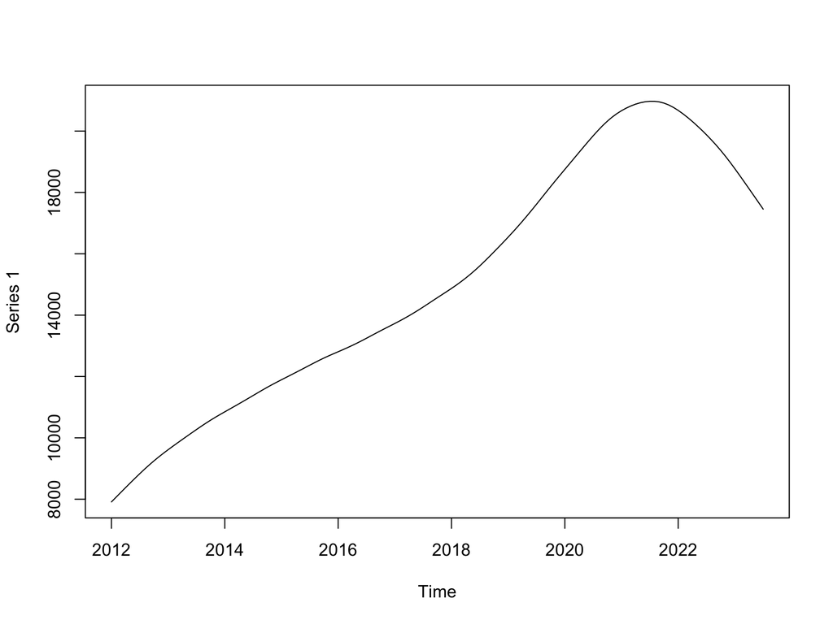

```r
#Calculo da tendencia pelo Filtro de Hodrick-Prescott
dadoshp <- hpfilter(exporta_manga_volume, type='lambda', freq=14400) #100 em dados anuais
plot(dadoshp$trend)
```

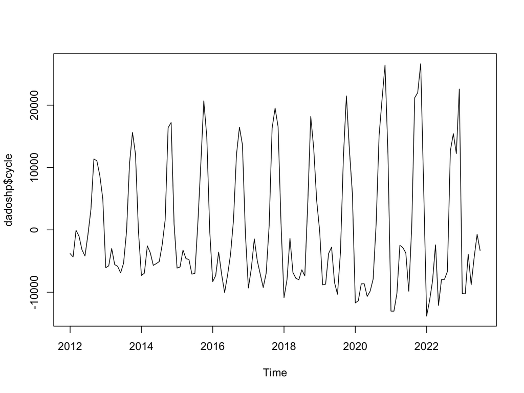

```r
plot(dadoshp$cycle)
```

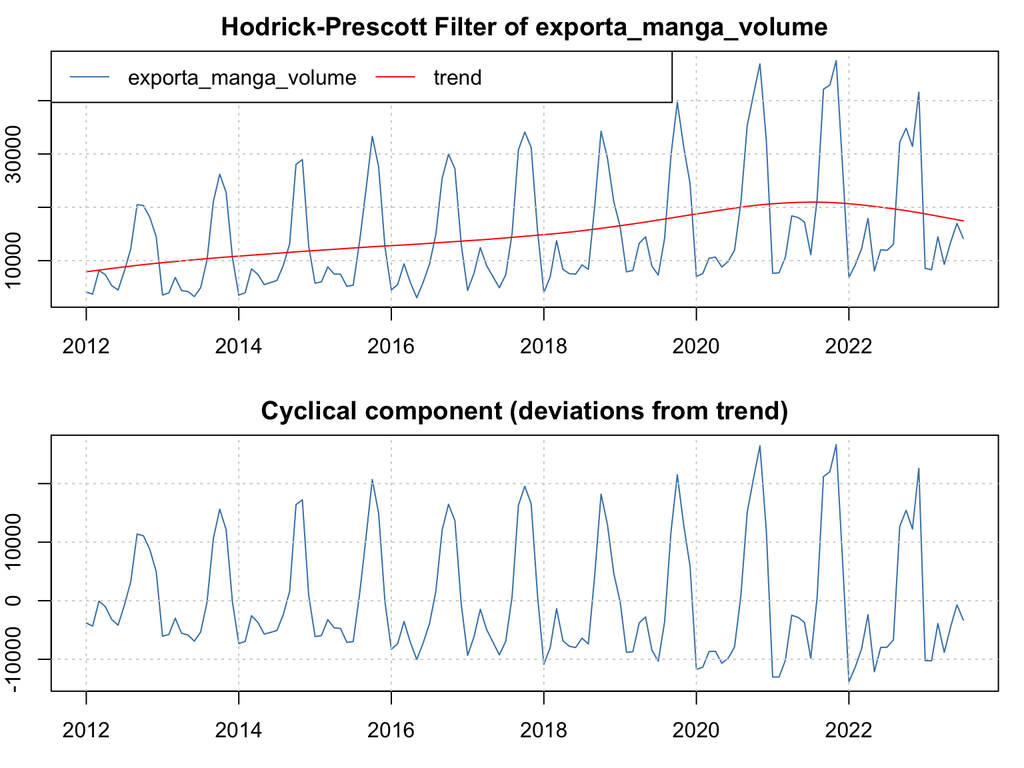

```r
plot(dadoshp)
```

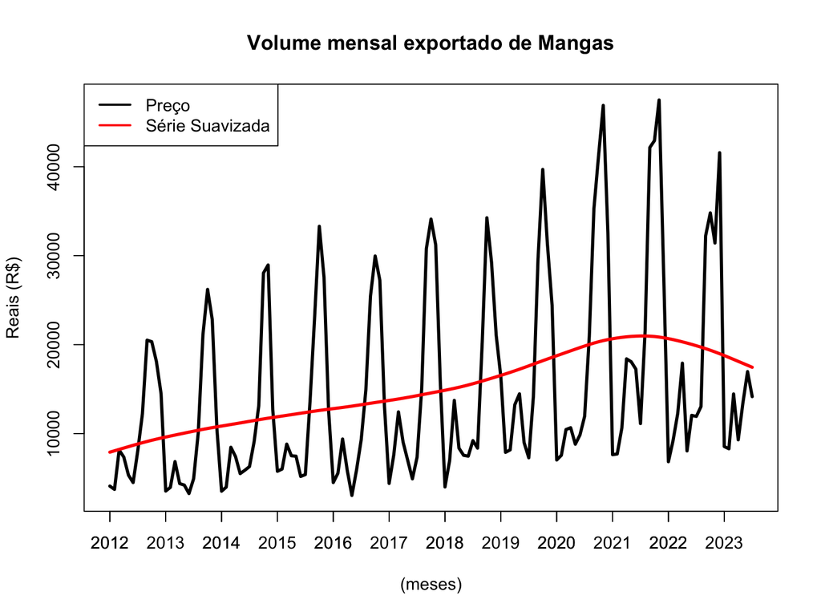

```r
#Graficos com o PRECO-HP

plot(exporta_manga_volume, main='Volume mensal exportado de Mangas',
     xlab='(meses)', ylab='Reais (R$)', lwd=3)
axis(1, at=c(2012:2023))
lines(dadoshp$trend, col='red', lwd=3)
legend('topleft', col=c('black','red'), lty=c(1,1), lwd=c(2,2),
       legend=c('Preço', 'Série Suavizada'))
```

# 3 Análise da Sazonalidade

**Variações sazonais** são movimentos cíclicos que se completam no período de um ano e se reproduzem nos outros anos com certa regularidade. Em outras palavras, *sazonalidade* significa dizer que em determinados meses os valores estão sistematicamente acima ou abaixo de um valor médio da série.

Assim, nos estudos normalmente se isola o componente sazonalidade por dois motivos:

1. Para estudar os outros componentes, como a tendência;
2. identificar os componentes sazonais que expressam a intensidade da sazonalidade a cada período.

## 3.1 Gráfico da Sazonalidade

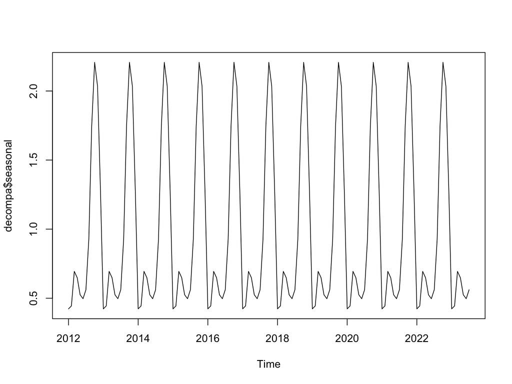

```r
#Mostrar apenas a Sazonalidade da Serie
plot(decompa$seasonal)
```

## 3.2 Gráfico dos Fatores Sazonais

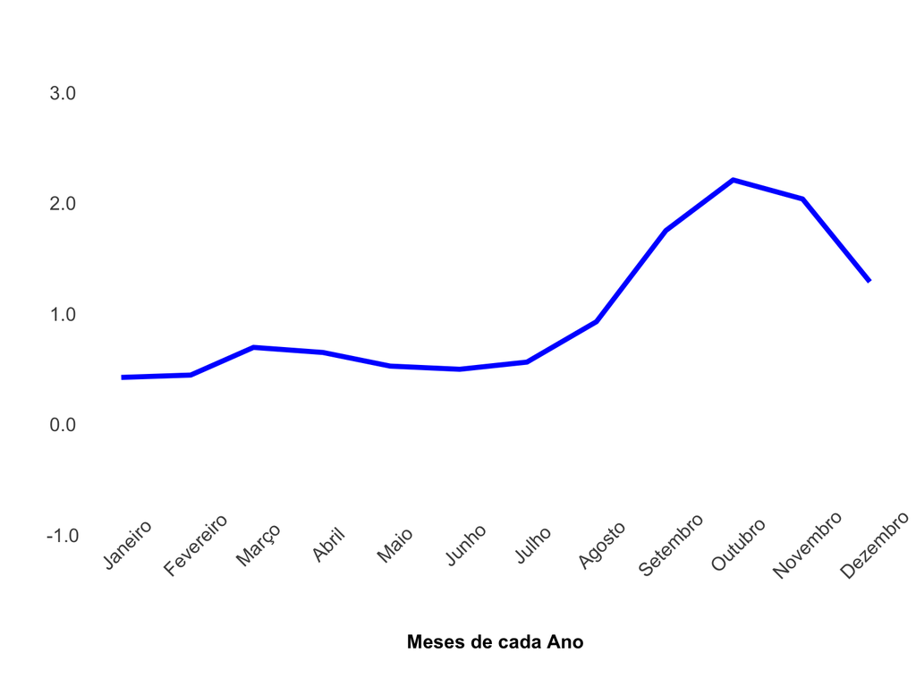

```r
decompa<-decompose(exporta_manga_volume, type = 'multiplicative')
sazonal_volume <- decompa$figure
meses <- seq(as.Date("2021/1/1"), by = "month", length.out = 12)
sazonal_graph_volume <- tibble(meses, sazonal_volume)

g6 <- ggplot(data=sazonal_graph_volume)+
  geom_line(aes(x=meses, y=sazonal_volume), color="blue", size=1.5)+
  scale_y_continuous(limits=c(-1,3), n.breaks = 5, expand = expansion(add=c(0,0.5)),
                     labels=number_format(accuracy = 0.1)) +
    scale_x_date(date_breaks = "1 month",
               labels = date_format("%B"))+
  labs(y= "", x= "Meses de cada Ano", title='',
       caption = "")+
  theme_minimal()+
  theme(axis.text.x=element_text(angle=45, hjust=0.5, size=12, margin = margin(b=10)),
        axis.text.y=element_text(hjust=0.5, size=12, margin = margin(l=10)),
        axis.title.y = element_text(size=12, face = "bold"),
        axis.title.x = element_text(size=12, face = "bold"),
        panel.grid.major = element_blank(),
        panel.grid.minor = element_blank(),
        plot.caption = element_text(hjust = 0, size=12),
        legend.position = "bottom", legend.title = element_blank(),
        legend.text=element_text(size=10)) # Definindo posição da legenda

g6
```

## 3.3 Análise da Sazonalidade com o seasplot

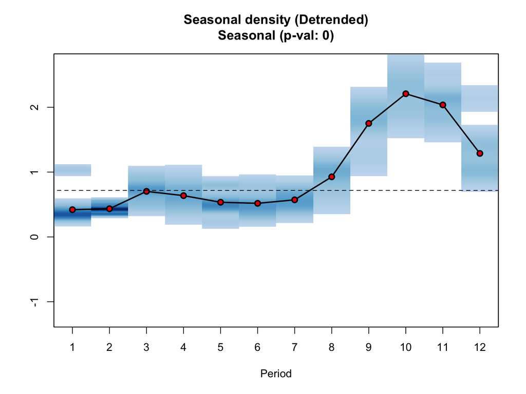

```
# Results of statistical testing
# Evidence of trend: TRUE  (pval: 0)
# Evidence of seasonality: TRUE  (pval: 0)
```

```r
seasplot(exporta_manga_volume, outplot = 5)
```

## 3.4 Sazonalidade - Regressão

A sazonalidade determinística pode ser analisada pelo **método de regressão** com o uso de *dummies* (binárias). Considere:

$$Y_t=T_t+S_t+\epsilon_t$$

em que a tendência é dada por por $T_t=\sum_{j=0}^{k}\beta_jt^j$;

Se a sazonalidade é determinística, o padrão sazonal não varia a cada ano e pode ser representado por 12 dummies sazonais $S_t=\sum_{j=1}^{12}\alpha_jd_{jt}$

Cada série de dummy sazonal da variável “y” pode ser facilmente gerada no R pelo comando `dseas1 <- seasonaldummy(y)`. Se a restrição $\sum_{j=i}^{12}d_j=0$ for usada, $\alpha_j$ representa o efeito sazonal do período “s” comparado com uma linha de tendencia média.

Estima-se o seguinte modelo:

$$Y_t=\sum_{j=0}^{k}\beta_jt^j+\sum_{j=1}^{11}\alpha_jD_{jt}+\epsilon_t$$

os coeficientes $\alpha_1, \alpha_2, \dots, \alpha_12$ são as constantes sazonais.

Dado que $\sum_{j=i}^{12}d_j=0$, $\alpha_{12}=-(\alpha_1+\alpha_2+ \dots+ \alpha_{11})$

## 3.5 Exemplo Sazonalidade Determinística por regressão no R

```r
#Geracao das variaveis Dummy Sazonais
exporta_manga_volume1 <- window(exporta_manga_volume, end=c(2022,12))
trend_volume <- cmav(exporta_manga_volume, outplot=F)
trend_volume1 <- window(trend_volume, end=c(2022,12))

dseas1 <- seasonaldummy(exporta_manga_volume1)
for(i in c(12, 24, 36, 48, 60, 72, 84, 96, 108, 120, 132)) {
  dseas1[i,] <- -1
}

#resultados ficarem com 4 casas decimais
#options(digits=4)

regressao5 <- lm(exporta_manga_volume1 ~ trend_volume1 + dseas1)
summary(regressao5)
```

```
#
# Call:
# lm(formula = exporta_manga_volume1 ~ trend_volume1 + dseas1)
#
# Residuals:
#     Min      1Q  Median      3Q     Max
# -9685.0 -2092.9   420.2  1940.5 16929.8
#
# Coefficients:
#                 Estimate Std. Error t value Pr(>|t|)
# (Intercept)   -4.358e+01  1.300e+03  -0.034    0.973
# trend_volume1  1.011e+00  8.333e-02  12.137  < 2e-16 ***
# dseas1Jan     -8.635e+03  1.114e+03  -7.751 3.42e-12 ***
# dseas1Feb     -8.426e+03  1.114e+03  -7.563 9.08e-12 ***
# dseas1Mar     -4.913e+03  1.114e+03  -4.411 2.28e-05 ***
# dseas1Apr     -4.941e+03  1.114e+03  -4.436 2.06e-05 ***
# dseas1May     -6.925e+03  1.114e+03  -6.219 7.71e-09 ***
# dseas1Jun     -7.467e+03  1.114e+03  -6.705 7.15e-10 ***
# dseas1Jul     -6.899e+03  1.114e+03  -6.195 8.65e-09 ***
# dseas1Aug     -1.459e+03  1.114e+03  -1.310    0.193
# dseas1Sep      1.130e+04  1.114e+03  10.146  < 2e-16 ***
# dseas1Oct      1.773e+04  1.114e+03  15.914  < 2e-16 ***
# dseas1Nov      1.564e+04  1.114e+03  14.040  < 2e-16 ***
# ---
# Signif. codes:  0 '***' 0.001 '**' 0.01 '*' 0.05 '.' 0.1 ' ' 1
#
# Residual standard error: 3858 on 119 degrees of freedom
# Multiple R-squared:  0.8901,  Adjusted R-squared:  0.879
# F-statistic: 80.32 on 12 and 119 DF,  p-value: < 2.2e-16
```

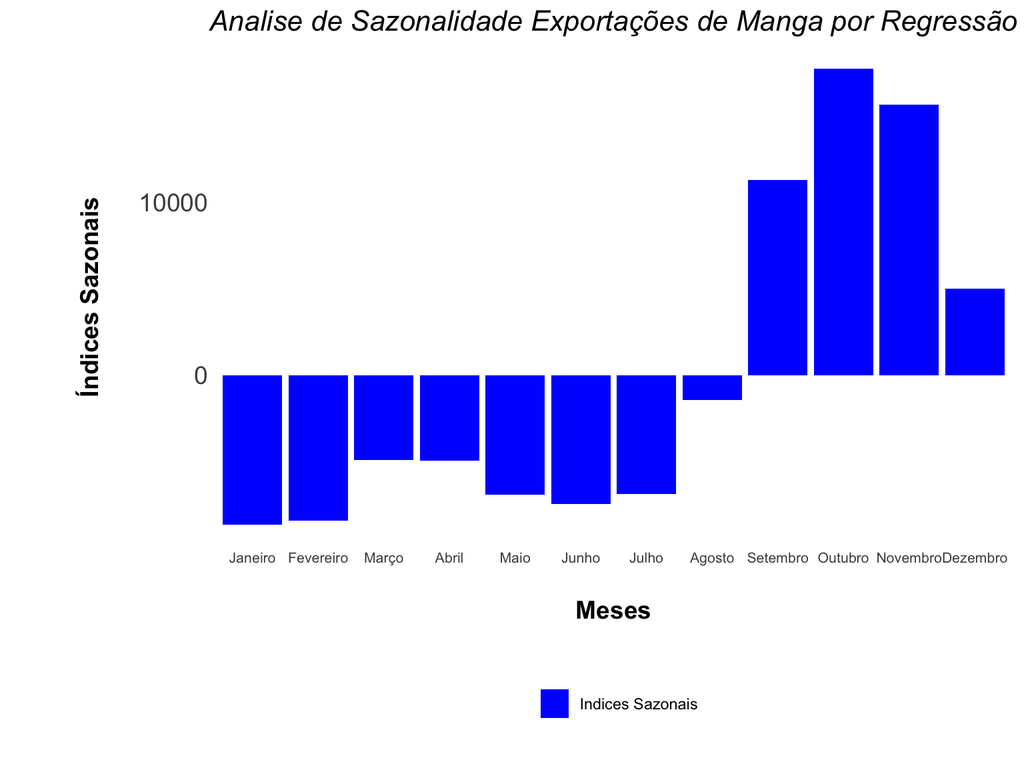

```r
# Organização dos Coeficientes da Regressão

coeffs <- coefficients(regressao5) #salva os coeficientes do modelo

#Calculo do efeito sazonal para dezembro como sendo o
#negativo do somatorio dos outros meses

dezembro <- as.data.frame(-(coeffs[3]+coeffs[4]+coeffs[5]+coeffs[6]+coeffs[7]+
                              coeffs[8]+coeffs[9]+coeffs[10]+coeffs[11]
                            +coeffs[12]+coeffs[13]))

colnames(dezembro)[1] <- "coeffs"
rownames(dezembro)[1] <- "Dezembro"

#salva os coeficientes estimados em um data frame
coeffs <- as.data.frame(coeffs)
rownames(coeffs) <- c("intercepto", "tendencia", "Janeiro", "Fevereiro", "Março",
                      "Abril", "Maio", "Junho", "Julho", "Agosto", "Setembro",
                      "Outubro", "Novembro")

# adiciona uma linha no primeiro data frame, juntando dezembro
# com os demais meses
indices_sazonais <- bind_rows(coeffs, dezembro)

#retira as duas primeiras linhas
indices_sazonais <- indices_sazonais %>% slice(-(1:2))

#cria uma variável "meses"
indices_sazonais$meses <- c("Janeiro", "Fevereiro", "Março",
                      "Abril", "Maio", "Junho", "Julho", "Agosto", "Setembro",
                      "Outubro", "Novembro", "Dezembro")

#Transforma a variável em um factor para fazer o gráfico sem mudar
#a ordem do eixo do x
indices_sazonais$meses <- factor(indices_sazonais$meses, levels = indices_sazonais$meses)

#Gráfico

mycolor1 <- "blue" #escolhe a cor do gráfico

ggplot(data=indices_sazonais, aes(x=meses, y=coeffs, fill="Indices Sazonais"))+
  geom_col()+
    scale_fill_manual(values=mycolor1)+
    labs(y= "Índices Sazonais", x= "Meses", title='Analise de Sazonalidade Exportações de Manga por Regressão',
       caption = "")+
    theme_minimal()+ #Definindo tema
    theme(axis.text.x=element_text(angle=0, hjust=0.5, size=8, margin = margin(b=20)),
        axis.text.y=element_text(hjust=1, size=14, margin = margin(l=20)),
        axis.title.x = element_text(size=14, face = "bold", margin = margin(b=20)),
        axis.title.y = element_text(size=14, face = "bold", margin = margin(l=40)),
        plot.title = element_text(hjust = 0.5, size=16, face="italic"),
        panel.grid.major = element_blank(),
        panel.grid.minor = element_blank(),
        plot.caption = element_text(hjust = 0, size=12),
        legend.position = 'bottom',
        legend.title = element_blank()) # Definindo posição da legenda
```

## 3.6 Análise da Tendência sem a Sazonalidade

```r
regressao6 <- lm(exporta_manga_volume1 ~ + dseas1)
summary(regressao6)
```

```
#
# Call:
# lm(formula = exporta_manga_volume1 ~ +dseas1)
#
# Residuals:
#    Min     1Q Median     3Q    Max
# -13557  -2692   -626   1542  21006
#
# Coefficients:
#             Estimate Std. Error t value Pr(>|t|)
# (Intercept)  15192.9      500.2  30.374  < 2e-16 ***
# dseas1Jan    -9036.1     1658.9  -5.447 2.77e-07 ***
# dseas1Feb    -8809.3     1658.9  -5.310 5.10e-07 ***
# dseas1Mar    -5249.2     1658.9  -3.164  0.00197 **
# dseas1Apr    -5176.9     1658.9  -3.121  0.00226 **
# dseas1May    -7055.7     1658.9  -4.253 4.20e-05 ***
# dseas1Jun    -7442.8     1658.9  -4.487 1.67e-05 ***
# dseas1Jul    -6753.2     1658.9  -4.071 8.43e-05 ***
# dseas1Aug    -1278.5     1658.9  -0.771  0.44242
# dseas1Sep    11521.6     1658.9   6.945 2.09e-10 ***
# dseas1Oct    17979.1     1658.9  10.838  < 2e-16 ***
# dseas1Nov    15930.2     1658.9   9.603  < 2e-16 ***
# ---
# Signif. codes:  0 '***' 0.001 '**' 0.01 '*' 0.05 '.' 0.1 ' ' 1
#
# Residual standard error: 5747 on 120 degrees of freedom
# Multiple R-squared:  0.7541,  Adjusted R-squared:  0.7315
# F-statistic: 33.45 on 11 and 120 DF,  p-value: < 2.2e-16
```

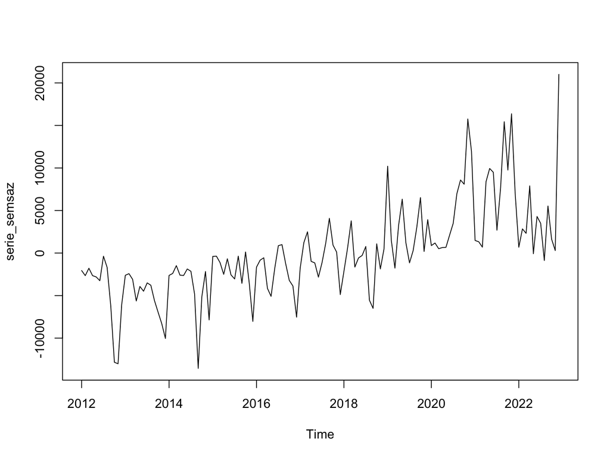

```r
serie_semsaz <- regressao6$residuals
serie_semsaz <- ts(serie_semsaz, start=c(2012,1), freq=12)

plot(serie_semsaz)
```

```r
trend <- 1:length(serie_semsaz) #geracao da variavel tendencia

regress7 <- lm(serie_semsaz ~ trend) #tendencia linear
summary(regress7)
```

```
#
# Call:
# lm(formula = serie_semsaz ~ trend)
#
# Residuals:
#      Min       1Q   Median       3Q      Max
# -10220.6  -2606.6   -312.6   2168.8  14483.3
#
# Coefficients:
#              Estimate Std. Error t value Pr(>|t|)
# (Intercept) -6622.798    697.267  -9.498   <2e-16 ***
# trend          99.591      9.098  10.947   <2e-16 ***
# ---
# Signif. codes:  0 '***' 0.001 '**' 0.01 '*' 0.05 '.' 0.1 ' ' 1
#
# Residual standard error: 3983 on 130 degrees of freedom
# Multiple R-squared:  0.4797,  Adjusted R-squared:  0.4757
# F-statistic: 119.8 on 1 and 130 DF,  p-value: < 2.2e-16
```